# Analysis of splicing variants using R

Author

Sri Harsha Meghadri

## Package Installations

This section will install a lot of libraries required for general bioinformatics analysis in R.

### Create a function to install multiple packages

comment it in by removing #

````markdown
```{r}
#ipak <- function(pkg){
#    new.pkg <- pkg[!(pkg %in% installed.packages()[, "Package"])]
#    if (length(new.pkg))
#        install.packages(new.pkg, dependencies = TRUE)
#    sapply(pkg, require, character.only = TRUE)
#}
```
````

````markdown
```{r}
#ipak(c("boot", "cluster", "codetools", "foreign", "KernSmooth", "lattice", "MASS", "Matrix", ""))
```
````

````markdown
```{r}
#bio_pkgs <- c("ggbio","biomaRt", "EnsDb.Hsapiens.v75", "renvcBioPortalData",
#          "GenomicRanges", "GenomicFeatures", "TxDb.Hsapiens.UCSC.hg19.knownGene", "Homo.sapiens", "AnnotationDbi", "edgeR", "DESeq2", "FRASER", "SplicingGraphs", "SeqGSEA", "SpliceWiz")
#BiocManager::install(bio_pkgs)
```
````

````markdown
```{r}
library(knitr)
library(data.table)
render_tidy_table <- function(data) {
  kable(data, options = list(
    width = '100%',
    align = 'c',
    style = 'striped',
    row.names = TRUE,
    header.style = list(
      background = '#fff',
      color = '#000'
    ),
    body.style = list(
      background = '#fff',
      color = '#000'
    )
  ))
}

# Function to format tibble data frame
format_tibble <- function(tibble, caption = "", col_widths = NULL) {
  # Set default column widths if not provided
  if (is.null(col_widths)) {
    col_widths = rep('auto', ncol(tibble))
  }

  # Convert tibble to HTML table with formatting
  kable(tibble, options = list(
    caption = caption,
    col.widths = col_widths,
    rowZebra = TRUE,
    align = 'c'
  )) %>%
    kableExtra::html_row(1, html = paste0('<b>', caption, '</b>'))
}
```
````

The idea here is to run the tutorial with the working example that is given in this [link](https://colab.research.google.com/drive/1OKT32eNIq7Cz839jjqz-GJlvoToPYbib). This will be then adjusted and run in a new notebook for the DMT1 analysis.

````markdown
```{r}
# Add the directory where installed libs are stored
.libPaths( c( .libPaths(), "/home/ngadmin/development/R_libraries/") )
```
````

````markdown
```{r}
# download required files
download.file(destfile="r-env-setup-script.R",
    url="https://raw.githubusercontent.com/c-mertes/RNAseq-ASHG19/master/r-env-setup-script.R")
source("r-env-setup-script.R")
```
````

```
## Update and install needed Ubuntu packages
## Download R package cache
## Unzipping R package cache
## Warning in system("tar -xzf r_binaries.tar.gz -C / ", intern = TRUE): running
## command 'tar -xzf r_binaries.tar.gz -C / ' had status 2
## Retrieve data for tutorials
```

````markdown
```{r}
print("Setup done.")
```
````

```
## [1] "Setup done."
```

````markdown
```{r}
library(OUTRIDER)
```
```{r}
library(annotables)
library(data.table)
library(ggplot2)
library(ggpubr)
library(shiny)
library(knitr)
library(tictoc)
```
````

Using the raw read counts and a sample annnotation we can find the gene expression outliers

````markdown
```{r}
#| column: screen-inset
#| layout-nrow: 1
anno <- fread("./annotation.tsv")[, 1:6]
cts <- as.matrix(read.table("./outrider/raw_counts.tsv.gz"))

#sneak peak into the data
render_tidy_table(head(anno))
print("Dimensions of the annotation:")
dim(anno)

cts[1:5, 1:10]
print("Dimensions of the count table:")
dim(cts)
```
````

| RNA_ID | SEX | ORIGIN | LAB | INDIVIDUAL | phase1TG |
| --- | --- | --- | --- | --- | --- |
| HG00096.1.M_111124_6 | male | British | UNIGE | HG00096 | 1 |
| HG00103.4.M_120208_3 | male | British | ICMB | HG00103 | 1 |
| HG00106.4.M_120208_5 | female | British | ICMB | HG00106 | 1 |
| HG00111.2.M_111215_4 | female | British | CNAG_CRG | HG00111 | 1 |
| HG00116.2.M_120131_1 | male | British | CNAG_CRG | HG00116 | 1 |
| HG00126.1.M_111124_8 | male | British | UNIGE | HG00126 | 1 |

```
## [1] "Dimensions of the annotation:"
## [1] 100   6
##                      HG00096 HG00103 HG00106 HG00111 HG00116 HG00126 HG00132
## ENSG00000000003.14_2       1       3       1      15       1       5       0
## ENSG00000000005.5_2        0       0       0       0       0       0       0
## ENSG00000000419.12_2     853    1131    1148    1341     863     948    1363
## ENSG00000000457.13_3     413     438     510     482     385     583     547
## ENSG00000000460.16_5     338     262     470     547     472     503     725
##                      HG00149 HG00150 HG00176
## ENSG00000000003.14_2       3       5       0
## ENSG00000000005.5_2        0       0       0
## ENSG00000000419.12_2     671    1452    1070
## ENSG00000000457.13_3     442     504     337
## ENSG00000000460.16_5     514     596     320
## [1] "Dimensions of the count table:"
## [1] 60829   100
```

Create an Outrider object with the loaded annotation and raw count matrix

````markdown
```{r}
anno[,sampleID:=INDIVIDUAL]
ods <- OutriderDataSet(countData = cts, colData = anno)
ods
```
````

```
## class: OutriderDataSet
## class: RangedSummarizedExperiment
## dim: 60829 100
## metadata(1): version
## assays(1): counts
## rownames(60829): ENSG00000000003.14_2 ENSG00000000005.5_2 ...
##   ENSG00000285993.1_1 ENSG00000285994.1_1
## rowData names(0):
## colnames(100): HG00096 HG00103 ... NA20805 NA20811
## colData names(7): RNA_ID SEX ... phase1TG sampleID
```

### QC and preprocessing of raw count data.

#### Size Factor

It represents the sequencing depth of each sample with respect to the others and is centered around 1. we can use `estimateSizeFactors` from DESeq2 and plot it.

Things to consider:

1. A low *sizeFactor* could be an indication for a failed experiment or issues with RNA preperation

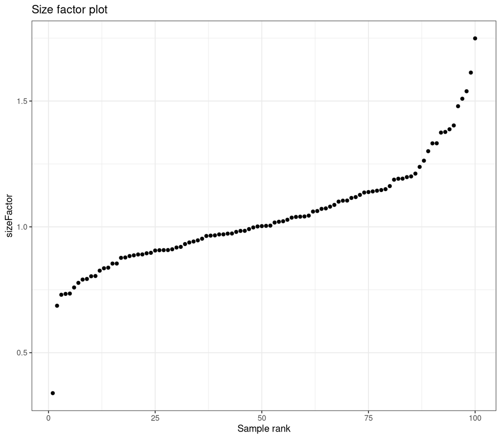

````markdown
```{r}
#| column: screen-inset
#| layout-nrow: 1
ods <- estimateSizeFactors(ods)
plotSizeFactors(ods)
```
````

##### Identify the sample with lowest *sizefactor*

````markdown
```{r}
round(sort(sizeFactors(ods)), digits = 2)[1:5]
```
````

```
## NA20778 NA20805 NA06984 NA20540 HG00278
##    0.34    0.69    0.73    0.73    0.74
```

#### Filtering non-expressed genes

- It is done to reove genes that are not expressed or/and of low quality.
- to detect outliers removing non expressed genes gives a more robust result
- As a good starting point keep genes where at least 5% of the samples have FPKM value greater than 1 (FPKM: Fragments per kilobase of transcript per million mapped reads)

````markdown
```{r}
txdb <- loadDb("annotations/gencode.v29lift37.annotation.txdb")
ods <- filterExpression(ods, gtfFile=txdb, filterGenes=FALSE)
```
````

```
## 45212 genes did not pass the filter. This is 74.3% of the genes.
```

- Plot the number of genes filtered out and their expression distributions across sample/gene pairs

```
## 3504263 sample-gene combinations are zero. This is 57.6% of the data
```

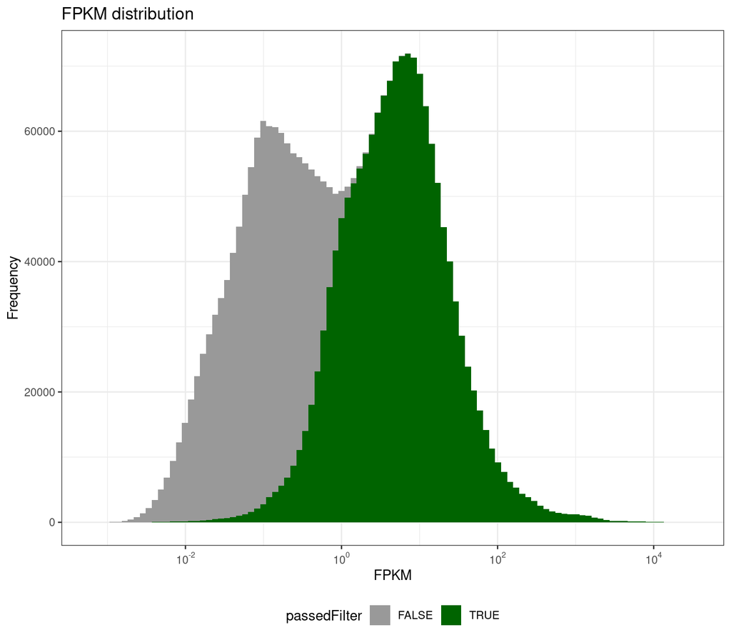

````markdown
```{r}
#| column: screen-inset
#| layout-nrow: 1
plotFPKM(ods) + theme(legend.position = 'bottom')
```
````

````markdown
```{r}
# filter object based on the expression status of the genes
ods <- ods[mcols(ods)[, "passedFilter"],]
ods
```
````

```
## class: OutriderDataSet
## class: RangedSummarizedExperiment
## dim: 15617 100
## metadata(1): version
## assays(1): counts
## rownames(15617): ENSG00000000419.12_2 ENSG00000000457.13_3 ...
##   ENSG00000285976.1_1 ENSG00000285979.1_1
## rowData names(3): loggeomeans passedFilter basepairs
## colnames(100): HG00096 HG00103 ... NA20805 NA20811
## colData names(13): sampleID RNA_ID ... passedFilterGenes
##   expressedGenesRank
```

### Sample co-variation

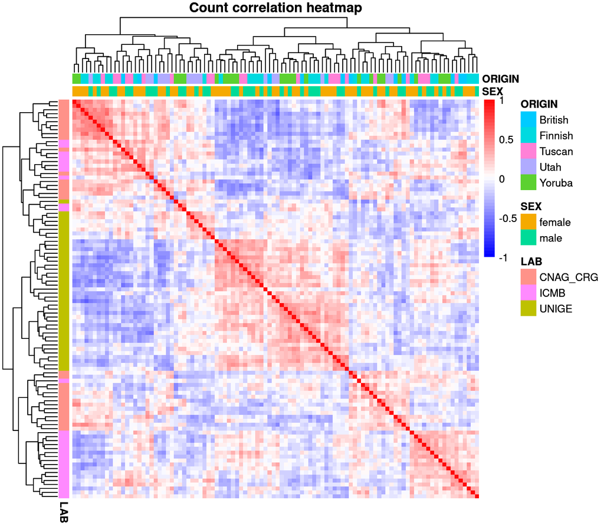

````markdown
```{r}
options(repr.plot.height = 5, repr.plot.width = 6)

# we will use normalize=FALSE since we have not corrected the data yet and cols from the #annotation to add labels to the heatmap
plotCountCorHeatmap(ods, colGroups=c("SEX", "ORIGIN"), rowGroups= "LAB", normalize= FALSE)
```
````

### Model Fitting

Using OUTRIDER to model sample co-variation. this is based on an autoencoder framework

````markdown
```{r}
tic()
register(MulticoreParam(workers = 4, tasks = 12, progressbar = TRUE))
ods <- readRDS("outrider/fitted_ods.RDS")
#ods <- findEncodingDim(ods)
getBestQ(ods)
toc()
#ods <- OUTRIDER(ods, q=getBestQ(ods))
```
````

```
## [1] 18
## 1.313 sec elapsed
```

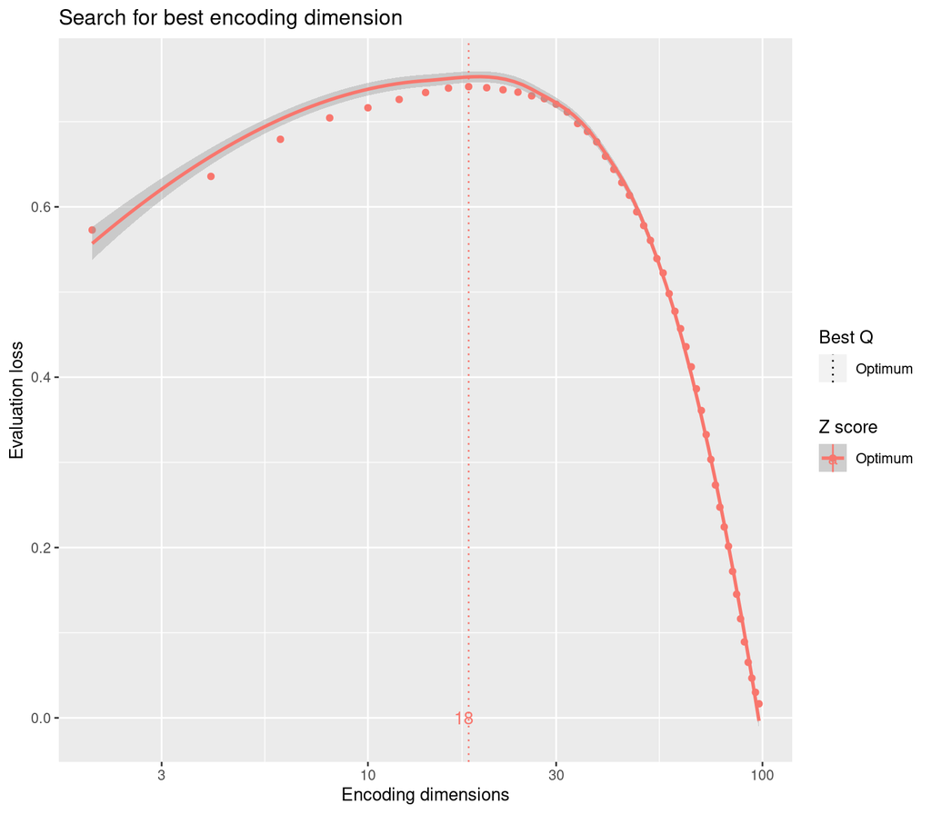

````markdown
```{r}
plotEncDimSearch(ods)
```
````

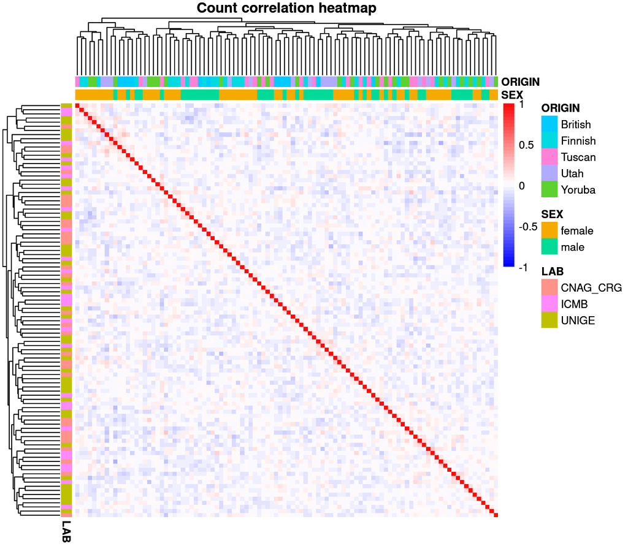

````markdown
```{r}
# Check the heatmap
plotCountCorHeatmap(ods, colGroups=c("SEX", "ORIGIN"), rowGroups="LAB", normalize=TRUE)
```
````

### Detection of Expression outliers

Outlier: An event that significantly deviates from the expected Negative-Bionomical distribution after controlling for confounders.

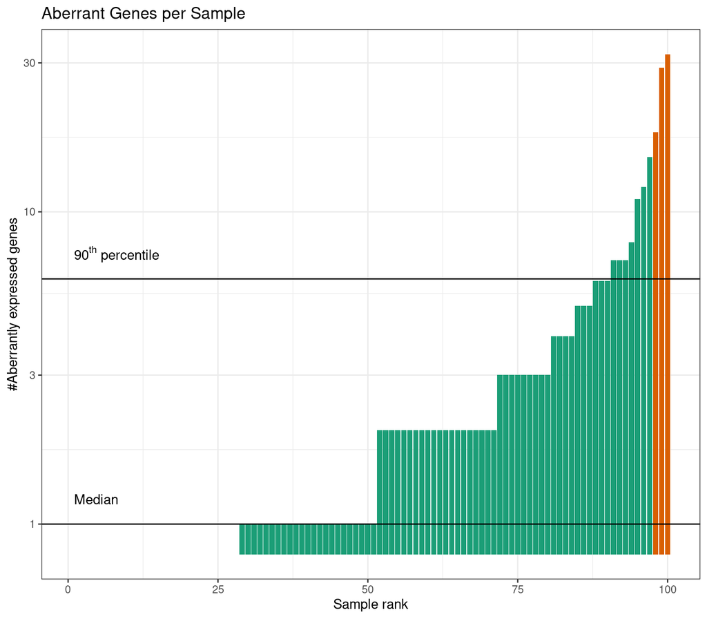

````markdown
```{r}
plotAberrantPerSample(ods)
```
````

#### What are the genes that are outliers.

````markdown
```{r}
geneIDs <- gsub("\\.[0-9]*(_[0-9]*)?.*$", "", rownames(ods))
map <- merge(data.table(ensgene=geneIDs), grch37, sort=FALSE, all.x=TRUE)[!duplicated(ensgene),]

# Set new gene names only if hgnc symbol is present
if(!"ENSG" %in% colnames(mcols(ods))){
  mcols(ods)$ENSG <- geneIDs
  rownames(ods) <- map[,ifelse(
    is.na(symbol) | symbol == "" | duplicated(symbol), geneIDs, symbol)]
}
```
````

Lets retrivve the expression outliers

````markdown
```{r}
res <- results(ods)
render_tidy_table(head(res))
dim(res)
```
````

| geneID | sampleID | pValue | padjust | zScore | l2fc | rawcounts | normcounts | meanCorrected | theta | aberrant | AberrantBySample | AberrantByGene | padj_rank |
| --- | --- | --- | --- | --- | --- | --- | --- | --- | --- | --- | --- | --- | --- |
| ZNF549 | NA12341 | 0 | 0 | -9.38 | -4.72 | 4 | 6.39 | 205.80 | 40.72 | TRUE | 11 | 1 | 1.0 |
| CAT | NA18873 | 0 | 0 | -9.17 | -5.37 | 24 | 29.43 | 1273.04 | 14.85 | TRUE | 4 | 1 | 1.0 |
| TXN2 | HG00103 | 0 | 0 | -8.39 | -1.37 | 852 | 1033.16 | 2679.52 | 103.84 | TRUE | 7 | 1 | 1.0 |
| FAM127A | NA06984 | 0 | 0 | -8.39 | -2.38 | 65 | 81.68 | 433.34 | 46.24 | TRUE | 18 | 1 | 1.0 |
| PARP4 | NA18916 | 0 | 0 | -8.34 | -2.21 | 833 | 585.46 | 2704.62 | 41.63 | TRUE | 8 | 1 | 1.5 |
| BRCC3 | NA18916 | 0 | 0 | 7.21 | 1.16 | 2689 | 1666.14 | 746.81 | 70.70 | TRUE | 8 | 1 | 1.5 |

```
## [1] 285  14
```

### Finding candidates in a patient.

As per the tutorial, sample NA18873 has a rare mitochondrial disease with complex 1 deficiency. This means we need to find MT genes abberently expressed.

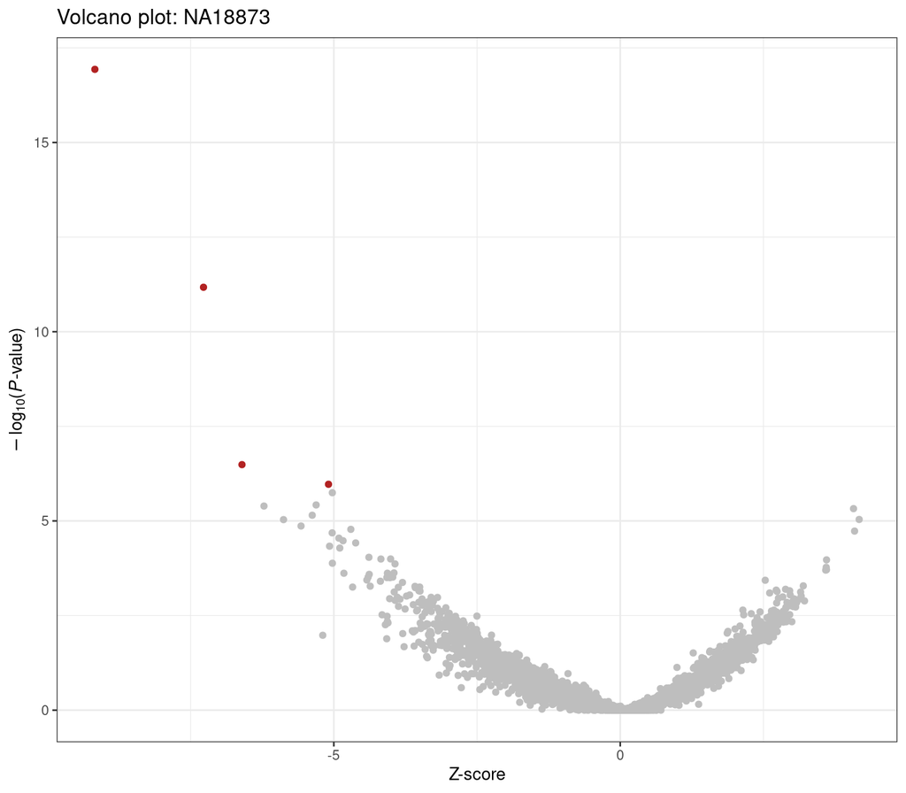

````markdown
```{r}
plotVolcano(ods, "NA18873", base=TRUE)
```
````

````markdown
```{r}
render_tidy_table(res[sampleID == "NA18873"])
```
````

| geneID | sampleID | pValue | padjust | zScore | l2fc | rawcounts | normcounts | meanCorrected | theta | aberrant | AberrantBySample | AberrantByGene | padj_rank |
| --- | --- | --- | --- | --- | --- | --- | --- | --- | --- | --- | --- | --- | --- |
| CAT | NA18873 | 0.0e+00 | 0.0000000 | -9.17 | -5.37 | 24 | 29.43 | 1273.04 | 14.85 | TRUE | 4 | 1 | 1 |
| TIMMDC1 | NA18873 | 0.0e+00 | 0.0000005 | -7.27 | -1.00 | 341 | 505.53 | 1013.88 | 158.36 | TRUE | 4 | 1 | 2 |
| RP11-325F22.2 | NA18873 | 3.0e-07 | 0.0173232 | -6.60 | -4.77 | 0 | 0.00 | 42.93 | 16.34 | TRUE | 4 | 1 | 3 |
| DCTD | NA18873 | 1.1e-06 | 0.0429285 | -5.09 | -0.45 | 1283 | 1542.44 | 2108.19 | 333.19 | TRUE | 4 | 1 | 4 |

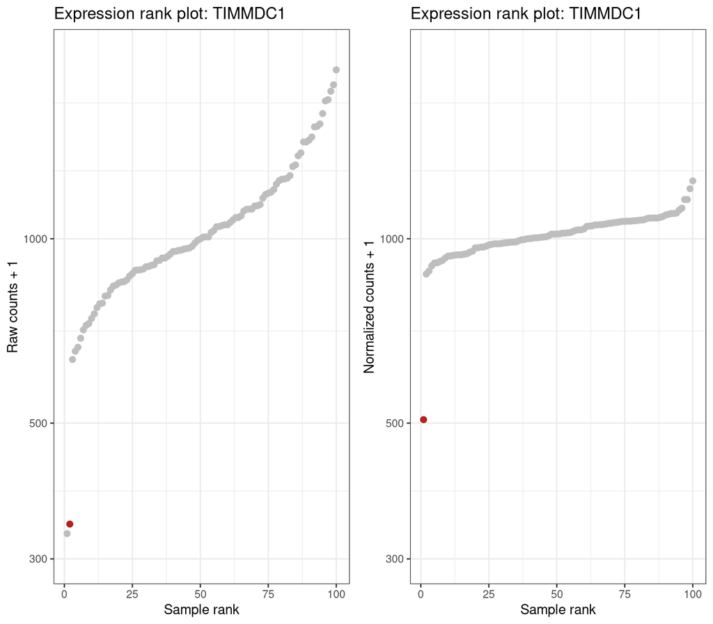

````markdown
```{r}
options(repr.plot.width=8, repr.plot.height=4)

ggarrange(ncol=2,
    plotExpressionRank(ods, "TIMMDC1", norm=FALSE, basePlot=TRUE) + scale_y_log10(lim=c(300,2000)),
    plotExpressionRank(ods, "TIMMDC1", norm=TRUE,  basePlot=TRUE) + scale_y_log10(lim=c(300,2000)))
```
````

# Aberrant Splicing Detection in RNA-Seq Data.

A comprehensive background on Splicing and how FRASER works is available at https://docs.google.com/presentation/d/1a7KZ6FXwVmGqF-FMAnz0QTk07WgzRWAbFhSNrUBspIQ/edit?pli=1#slide=id.g64b01c344e_4_394

Here we will focus on loading the packages and executing the tutorial.

````markdown
```{r}
library(FRASER)
```
```{r}
library(data.table)
library(ggplot2)
library(ggpubr)
register(SerialParam())
```
````

````markdown
```{r}
anno_fras <- fread("annotation.tsv")[,1:6]
anno_fras[, sampleID:=INDIVIDUAL]
junctionCts <- fread("./splicing/raw_junction_counts.tsv.gz")
spliceSiteCts <- fread("./splicing/raw_site_counts.tsv.gz")
```
````

````markdown
```{r}
render_tidy_table(head(anno_fras))
render_tidy_table(junctionCts[1:6, 1:15])
render_tidy_table(spliceSiteCts[1:6, 1:15])
```
````

| RNA_ID | SEX | ORIGIN | LAB | INDIVIDUAL | phase1TG | sampleID |
| --- | --- | --- | --- | --- | --- | --- |
| HG00096.1.M_111124_6 | male | British | UNIGE | HG00096 | 1 | HG00096 |
| HG00103.4.M_120208_3 | male | British | ICMB | HG00103 | 1 | HG00103 |
| HG00106.4.M_120208_5 | female | British | ICMB | HG00106 | 1 | HG00106 |
| HG00111.2.M_111215_4 | female | British | CNAG_CRG | HG00111 | 1 | HG00111 |
| HG00116.2.M_120131_1 | male | British | CNAG_CRG | HG00116 | 1 | HG00116 |
| HG00126.1.M_111124_8 | male | British | UNIGE | HG00126 | 1 | HG00126 |

| seqnames | start | end | width | strand | startID | endID | HG00096 | HG00103 | HG00106 | HG00111 | HG00116 | HG00126 | HG00132 | HG00149 |
| --- | --- | --- | --- | --- | --- | --- | --- | --- | --- | --- | --- | --- | --- | --- |
| chr1 | 12228 | 12594 | 367 | * | 1 | 685990 | 0 | 0 | 0 | 0 | 0 | 0 | 0 | 1 |
| chr1 | 12722 | 13224 | 503 | * | 2 | 685991 | 0 | 0 | 0 | 0 | 0 | 0 | 0 | 0 |
| chr1 | 13053 | 13220 | 168 | * | 3 | 685992 | 0 | 0 | 0 | 0 | 0 | 0 | 0 | 0 |
| chr1 | 14598 | 1378195 | 1363598 | * | 4 | 685993 | 0 | 0 | 0 | 0 | 0 | 0 | 0 | 0 |
| chr1 | 14708 | 14708 | 1 | * | 5 | 685994 | 0 | 0 | 0 | 0 | 0 | 0 | 0 | 0 |
| chr1 | 14738 | 14969 | 232 | * | 6 | 685995 | 0 | 0 | 0 | 1 | 0 | 0 | 0 | 0 |

| seqnames | start | end | width | strand | spliceSiteID | type | HG00096 | HG00103 | HG00106 | HG00111 | HG00116 | HG00126 | HG00132 | HG00149 |
| --- | --- | --- | --- | --- | --- | --- | --- | --- | --- | --- | --- | --- | --- | --- |
| chr1 | 14829 | 14830 | 2 | * | 12 | Donor | 10 | 7 | 9 | 18 | 4 | 10 | 0 | 8 |
| chr1 | 14969 | 14970 | 2 | * | 685995 | Acceptor | 18 | 22 | 22 | 41 | 17 | 19 | 8 | 17 |
| chr1 | 15038 | 15039 | 2 | * | 16 | Donor | 5 | 3 | 7 | 6 | 1 | 3 | 0 | 6 |
| chr1 | 15795 | 15796 | 2 | * | 686004 | Acceptor | 3 | 3 | 5 | 4 | 1 | 1 | 0 | 0 |
| chr1 | 17055 | 17056 | 2 | * | 38 | Donor | 1 | 0 | 1 | 0 | 0 | 0 | 0 | 1 |
| chr1 | 17232 | 17233 | 2 | * | 686023 | Acceptor | 2 | 1 | 1 | 0 | 0 | 1 | 0 | 0 |

````markdown
```{r}
# Create a FRASER object

fds <- FraserDataSet(colData = anno_fras, junctions = junctionCts, spliceSites = spliceSiteCts)

fds
```
````

```
## -------------------- Sample data table -----------------
## # A tibble: 100 × 7
##    RNA_ID               SEX    ORIGIN  LAB      INDIVIDUAL phase1TG sampleID
##    <chr>                <chr>  <chr>   <chr>    <chr>         <int> <chr>
##  1 HG00096.1.M_111124_6 male   British UNIGE    HG00096           1 HG00096
##  2 HG00103.4.M_120208_3 male   British ICMB     HG00103           1 HG00103
##  3 HG00106.4.M_120208_5 female British ICMB     HG00106           1 HG00106
##  4 HG00111.2.M_111215_4 female British CNAG_CRG HG00111           1 HG00111
##  5 HG00116.2.M_120131_1 male   British CNAG_CRG HG00116           1 HG00116
##  6 HG00126.1.M_111124_8 male   British UNIGE    HG00126           1 HG00126
##  7 HG00132.2.M_111215_4 female British CNAG_CRG HG00132           0 HG00132
##  8 HG00149.1.M_111124_6 male   British UNIGE    HG00149           1 HG00149
##  9 HG00150.4.M_120208_7 female British ICMB     HG00150           1 HG00150
## 10 HG00176.4.M_120208_2 female Finnish ICMB     HG00176           1 HG00176
## # ℹ 90 more rows
##
## Number of samples:      100
## Number of junctions:    1178543
## Number of splice sites: 216897
## assays(2): rawCountsJ rawCountsSS
##
## ----------------------- Settings -----------------------
## Analysis name:               Data Analysis
## Analysis is strand specific: no
## Working directory:           'FRASER_output'
##
## -------------------- BAM parameters --------------------
## Default used with: bamMapqFilter=0
```

````markdown
```{r}
set.seed(42)
patient_ids <- c("NA11918", "NA20505", "HG00132")
fds <- fds <- fds[
    seqnames(fds) %in% c("chr3", "chr6", "chr19"),
    unique(c(patient_ids, sample(colnames(fds))))[1:60]]
dontWriteHDF5(fds) <- TRUE
fds
```
````

```
## -------------------- Sample data table -----------------
## # A tibble: 60 × 7
##    RNA_ID               SEX    ORIGIN  LAB      INDIVIDUAL phase1TG sampleID
##    <chr>                <chr>  <chr>   <chr>    <chr>         <int> <chr>
##  1 NA11918.1.M_111124_3 female Utah    UNIGE    NA11918           0 NA11918
##  2 NA20505.1.M_111124_6 female Tuscan  UNIGE    NA20505           1 NA20505
##  3 HG00132.2.M_111215_4 female British CNAG_CRG HG00132           0 HG00132
##  4 NA12413.2.M_111215_6 male   Utah    CNAG_CRG NA12413           1 NA12413
##  5 NA19102.1.M_111124_1 female Yoruba  UNIGE    NA19102           1 NA19102
##  6 HG00326.1.M_111124_7 female Finnish UNIGE    HG00326           1 HG00326
##  7 NA19207.4.M_120208_5 male   Yoruba  ICMB     NA19207           1 NA19207
##  8 HG00265.2.M_111215_4 male   British CNAG_CRG HG00265           1 HG00265
##  9 NA20811.1.M_111124_5 male   Tuscan  UNIGE    NA20811           1 NA20811
## 10 NA12341.1.M_111124_5 female Utah    UNIGE    NA12341           1 NA12341
## # ℹ 50 more rows
##
## Number of samples:      60
## Number of junctions:    199571
## Number of splice sites: 36134
## assays(2): rawCountsJ rawCountsSS
##
## ----------------------- Settings -----------------------
## Analysis name:               Data Analysis
## Analysis is strand specific: no
## Working directory:           'FRASER_output'
##
## -------------------- BAM parameters --------------------
## Default used with: bamMapqFilter=0
```

### Filtering of data.

1. Calculate the splicing metric with Percent Spliced In (PSI) and Splicing efficiency.
2. Create filters such as min reads required per sample or the % of the samples having x reads at the least.
3. At least one sample has to have |Δ𝜓|>0.1

[output not shown]

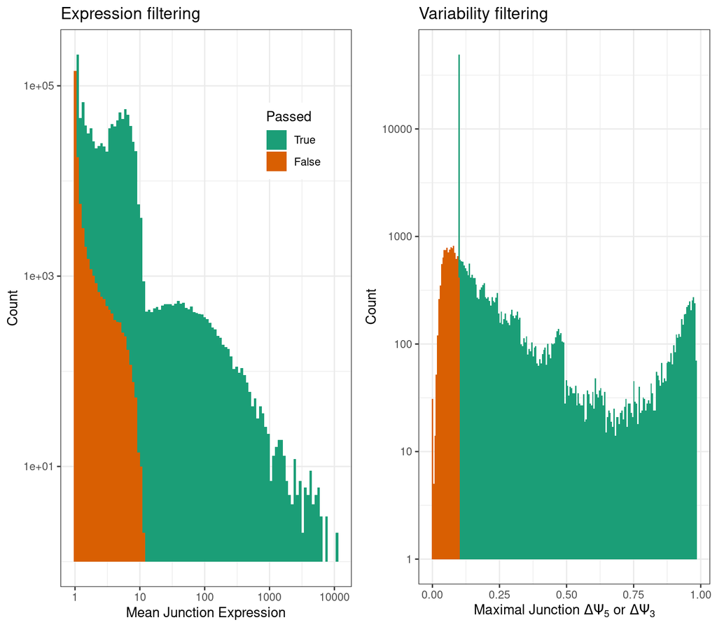

````markdown
```{r}
options(repr.plot.width = 5, repr.plot.height = 4)

pfe1 <- plotFilterExpression(fds, bins=100)
pfe2 <- plotFilterVariability(fds) + theme(legend.position = "none")
ggarrange(pfe1, pfe2, ncol = 2)
```
````

````markdown
```{r}
fds <- fds[mcols(fds, type= "j")[,"passed"],]
fds
```
````

```
## -------------------- Sample data table -----------------
## # A tibble: 60 × 7
##    RNA_ID               SEX    ORIGIN  LAB      INDIVIDUAL phase1TG sampleID
##    <chr>                <chr>  <chr>   <chr>    <chr>         <int> <chr>
##  1 NA11918.1.M_111124_3 female Utah    UNIGE    NA11918           0 NA11918
##  2 NA20505.1.M_111124_6 female Tuscan  UNIGE    NA20505           1 NA20505
##  3 HG00132.2.M_111215_4 female British CNAG_CRG HG00132           0 HG00132
##  4 NA12413.2.M_111215_6 male   Utah    CNAG_CRG NA12413           1 NA12413
##  5 NA19102.1.M_111124_1 female Yoruba  UNIGE    NA19102           1 NA19102
##  6 HG00326.1.M_111124_7 female Finnish UNIGE    HG00326           1 HG00326
##  7 NA19207.4.M_120208_5 male   Yoruba  ICMB     NA19207           1 NA19207
##  8 HG00265.2.M_111215_4 male   British CNAG_CRG HG00265           1 HG00265
##  9 NA20811.1.M_111124_5 male   Tuscan  UNIGE    NA20811           1 NA20811
## 10 NA12341.1.M_111124_5 female Utah    UNIGE    NA12341           1 NA12341
## # ℹ 50 more rows
##
## Number of samples:      60
## Number of junctions:    12535
## Number of splice sites: 23696
## assays(11): rawCountsJ psi5 ... rawOtherCounts_theta delta_theta
##
## ----------------------- Settings -----------------------
## Analysis name:               Data Analysis
## Analysis is strand specific: no
## Working directory:           'FRASER_output'
##
## -------------------- BAM parameters --------------------
## Default used with: bamMapqFilter=0
```

- have a look into our data to see if we do have correlation structure or not. To have a better estimate, we use the logit transformed 𝜓 values to compute the correlation. We can annotate our plot with any information provided through the sample annotation.

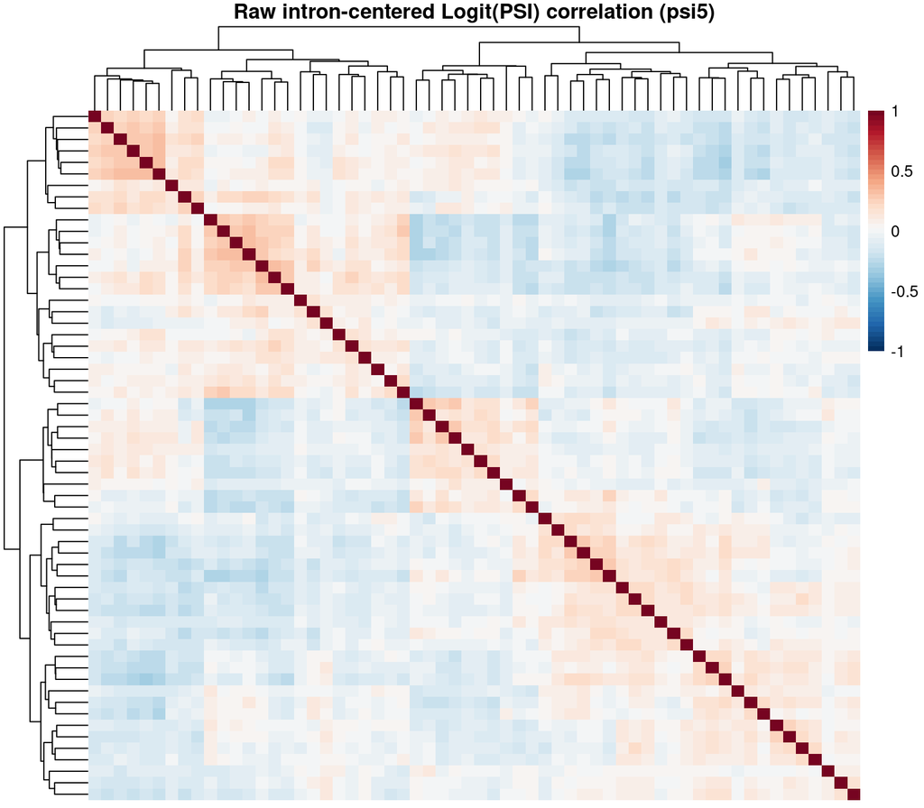

````markdown
```{r}
options(repr.plot.height = 5, repr.plot.width = 6)

plotCountCorHeatmap(fds, type= "psi5", logit=TRUE, sampleClustering=NA, annotation_cols=c("SEX", "LAB", "ORIGIN"))
```
````

Here I am training the model from scratch to see if this can be performed in the server (time consuming so you can skip if the model has already been stored)

````markdown
```{r}
#register(MulticoreParam(workers = 4, tasks = 20, progressbar = TRUE))
#tic(msg = "Starting the loop")
#for(i in psiTypes) {
#  fds <- optimHyperParams(fds, i)
#  bestQ(fds,i)
#  plotEncDimSearch(fds, i)
#}
#toc(log = TRUE)
```
````

````markdown
```{r}
#fds <- FRASER(fds) # uncommented because i have loaded fds from ./splicing/fitted_fds.RDS
fds <- readRDS("splicing/fitted_fds.RDS")
```
````

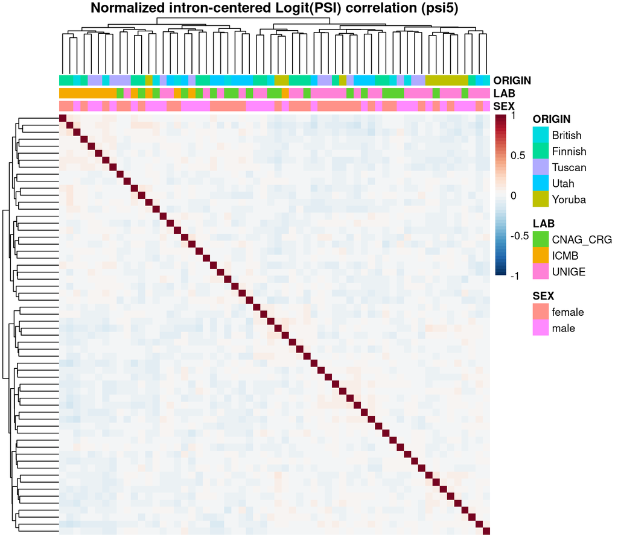

````markdown
```{r}
plotCountCorHeatmap(fds, type="psi5", normalized=TRUE, logit=TRUE,
                    topN=15000, annotation_col=c("SEX", "LAB", "ORIGIN"), sampleClustering=NA)
```
````

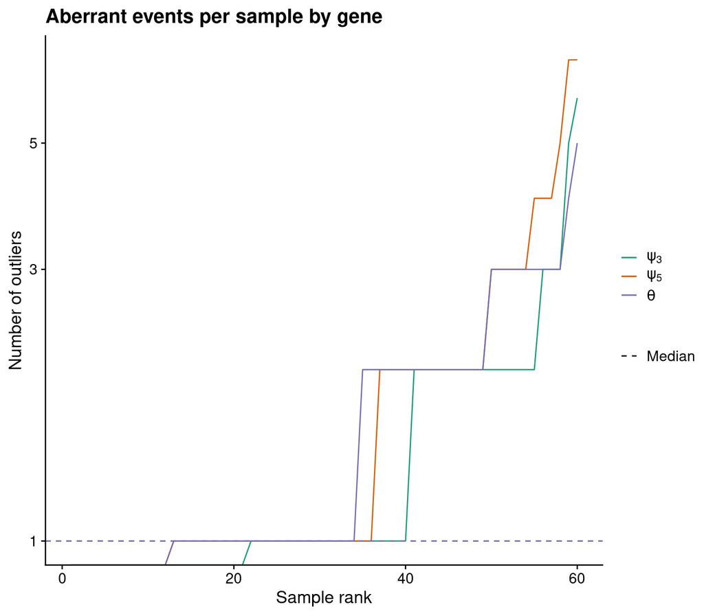

````markdown
```{r}
plotAberrantPerSample(fds)
```
````

````markdown
```{r}
fds <- annotateRangesWithTxDb(fds)
```
````

[output not shown]

````markdown
```{r}
register(SerialParam())
res <- as.data.table(results(fds))
```
````

```
## Tue Nov 28 13:51:05 2023: Collecting results for: psi3
## Tue Nov 28 13:51:05 2023: Process chunk: 1 for: psi3
## Tue Nov 28 13:51:08 2023: Collecting results for: psi5
## Tue Nov 28 13:51:08 2023: Process chunk: 1 for: psi5
## Tue Nov 28 13:51:12 2023: Collecting results for: theta
## Tue Nov 28 13:51:12 2023: Process chunk: 1 for: theta
```

````markdown
```{r}
res
```
````

```
##      seqnames     start       end width strand sampleID hgncSymbol
##   1:    chr10   7838119   7844232  6114      *  HG00342    ATP5F1C
##   2:    chr10   7842055   7844232  2178      *  HG00342    ATP5F1C
##   3:    chr10   7838119   7839009   891      *  HG00342    ATP5F1C
##   4:    chr10   7838119   7844232  6114      *  HG00342    ATP5F1C
##   5:    chr16  11931951  11931952     2      *  NA20754     RSL1D1
##  ---
## 352:     chr8  22573576  22602106 28531      *  HG00282      PEBP4
## 353:     chr8  22577198  22602106 24909      *  HG00282      PEBP4
## 354:    chr22  36635486  36635487     2      *  NA19153      APOL2
## 355:     chr6  31946776  31947190   415      *  NA20505       <NA>
## 356:     chr3 132322172 132323941  1770      *  NA11994     ACAD11
##      addHgncSymbols  type     pValue    padjust zScore psiValue deltaPsi
##   1:                 psi3 2.5729e-25 1.9289e-19   7.19     0.75     0.75
##   2:                 psi3 2.5729e-25 1.9289e-19  -6.11     0.24    -0.75
```

[output cut: 21 more lines]

````markdown
```{r}
resAsGR <- makeGRangesFromDataFrame(res, keep.extra.columns = TRUE)

# group results by genes/sample
results_by_genes <- as.data.table(resultsByGenes(resAsGR))
results_by_genes
```
````

```
##      seqnames     start       end width strand sampleID hgncSymbol
##   1:    chr10   7838119   7844232  6114      *  HG00342    ATP5F1C
##   2:    chr16  11931951  11931952     2      *  NA20754     RSL1D1
##   3:     chr3 119232567 119234706  2140      *  NA11918    TIMMDC1
##   4:     chr6  32487429  32551885 64457      *  NA20505   HLA-DRB5
##   5:     chrX  12994147  12994148     2      *  HG00367     TMSB4X
##  ---
## 139:     chr9    162470    163977  1508      *  NA19116      CBWD1
## 140:     chr7  56079563  56088765  9203      *  NA19096       PSPH
## 141:    chr21  38569998  38572532  2535      *  HG00282       TTC3
## 142:     chr8  22573576  22602106 28531      *  HG00282      PEBP4
## 143:     chr3 132322172 132323941  1770      *  NA11994     ACAD11
##      addHgncSymbols  type     pValue    padjust zScore psiValue deltaPsi
##   1:                 psi3 2.5729e-25 1.9289e-19   7.19     0.75     0.75
##   2:                theta 2.0795e-23 3.3028e-17  -7.15     0.48    -0.52
```

[output cut: 21 more lines]

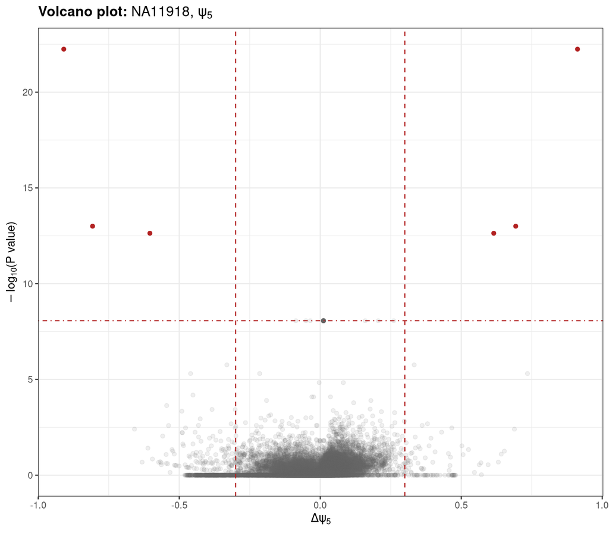

````markdown
```{r}
options(repr.plot.width = 4, repr.plot.height = 4)
plotVolcano(fds, type="psi5", "NA11918")
```
````

Identifying splicing events in detail

````markdown
```{r}
res[sampleID == "NA11918"]
```
````

```
##     seqnames     start       end  width strand sampleID hgncSymbol
##  1:     chr3 119232567 119234706   2140      *  NA11918    TIMMDC1
##  2:     chr3 119232567 119236051   3485      *  NA11918    TIMMDC1
##  3:     chr3 119232567 119236051   3485      *  NA11918    TIMMDC1
##  4:     chr3 119234787 119236051   1265      *  NA11918    TIMMDC1
##  5:     chr2  89278229  89327132  48904      *  NA11918       <NA>
##  6:     chr2  89326964  89327132    169      *  NA11918       <NA>
##  7:     chrX  70280969  70281692    724      *  NA11918      SNX12
##  8:     chrX  70280969  70282703   1735      *  NA11918      SNX12
##  9:     chr5  80770382  80911291 140910      *  NA11918      SSBP2
## 10:     chr5  80809537  80911291 101755      *  NA11918      SSBP2
## 11:     chr5  80770382  80785068  14687      *  NA11918      SSBP2
## 12:     chr5  80770382  80911291 140910      *  NA11918      SSBP2
## 13:     chrX  70280969  70282703   1735      *  NA11918      SNX12
## 14:     chrX  70281818  70282703    886      *  NA11918      SNX12
```

[output cut: 60 more lines]

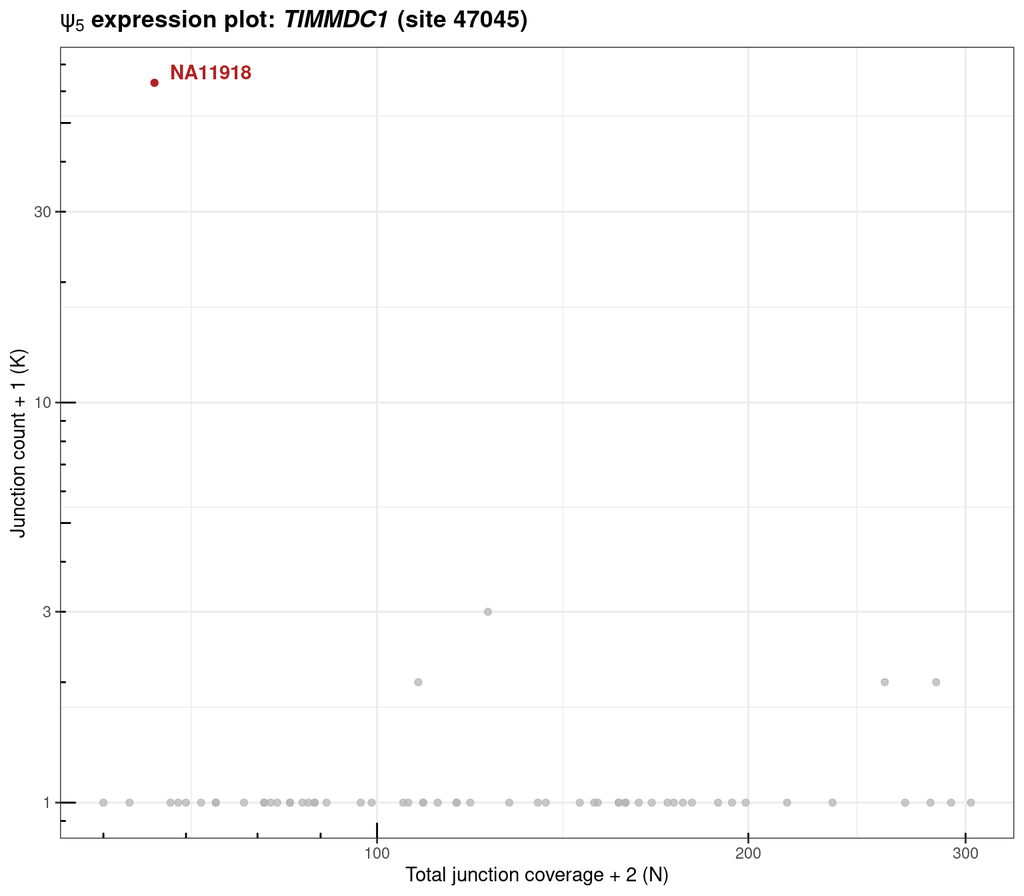

````markdown
```{r}
plotExpression(fds, type="psi5", result=res[sampleID == "NA11918" & hgncSymbol == "TIMMDC1"][1])
```
````

```
## $`1`
##
## $`2`
##
## attr(,"class")
## [1] "list"      "ggarrange"
```

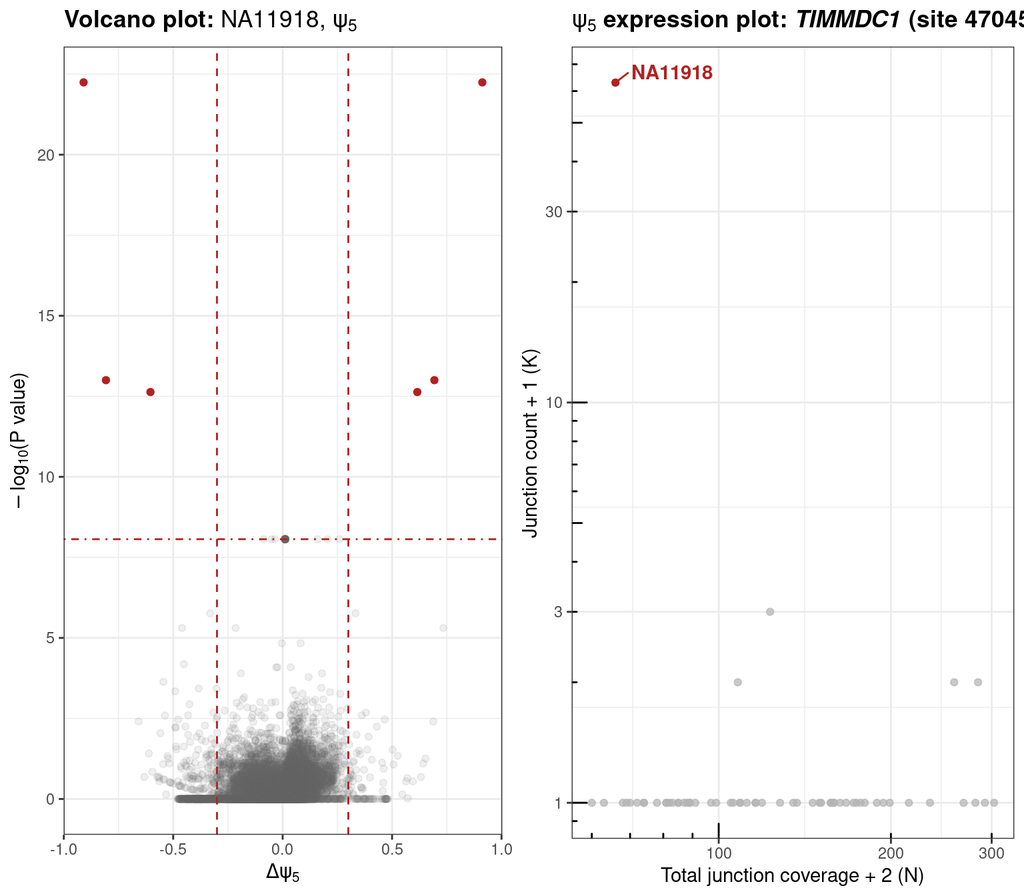

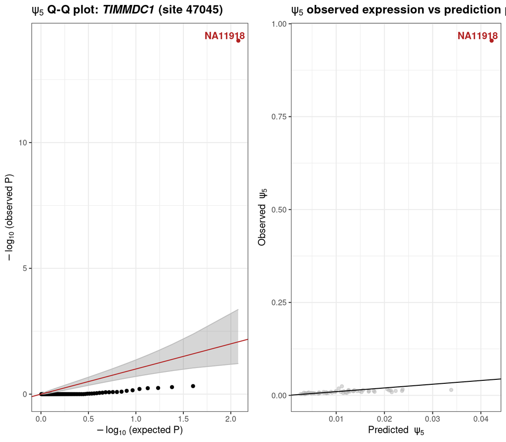

````markdown
```{r}
# Make the plotting area t fit 4 panels
options(repr.plot.height = 4, repr.plot.width = 9)

res2plot <- res[sampleID == "NA11918" & hgncSymbol == "TIMMDC1"][1,]
ggarrange(ncol = 2,
          plotVolcano(fds, type= "psi5", "NA11918"),
          plotExpression(fds, result = res2plot),
          plotQQ(fds, result=res2plot),
          plotExpectedVsObservedPsi(fds, result = res2plot))
```
````

## Mono Allelic expression

````markdown
```{r}
#BiocManager::install("GenomicScores")
#remotes::install_github("gagneurlab/tMAE")
```
````

````markdown
```{r}
library(ggplot2)
library(data.table)
library(tMAE)
```
````

````markdown
```{r}
allelicCountsFile <- 'https://i12g-gagneurweb.in.tum.de/public/workshops/RNAseq_ASHG19/input_data/mae/allelic_counts.tsv.gz'
allelicCounts <- fread(allelicCountsFile)

# print data
allelicCounts[1:4,]
dim(allelicCounts)
```
````

```
##    contig  position  variantID refAllele altAllele refCount altCount totalCount
## 1:   chr1 150783825 rs10305750         C         T       30       29         59
## 2:   chr1  42898843  rs1034268         A         G        2        2          4
## 3:   chr1  42898843  rs1034268         A         G        1        6          7
## 4:   chr1  19411129  rs1043905         A         G      112      116        228
##    lowMAPQDepth lowBaseQDepth rawDepth otherBases improperPairs  MAE_ID
## 1:            0             0       60          0             1 HG00106
## 2:            0             0        4          0             0 HG00111
## 3:            0             0        8          0             1 HG00106
## 4:            0             0      233          2             3 HG00111
## [1] 2866   14
```

````markdown
```{r}
print('IDs in table')
unique(allelicCounts$MAE_ID)
```
````

```
## [1] "IDs in table"
## [1] "HG00106" "HG00111"
```

Plot counts of alternative vs reference allele.

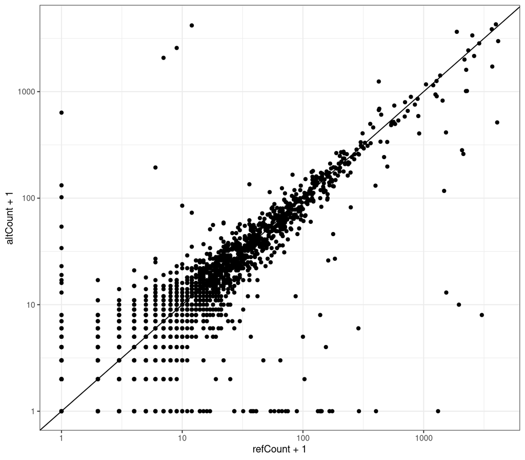

````markdown
```{r}
ggplot(allelicCounts, aes(refCount+1, altCount+1)) + geom_point() + geom_abline(slope = 1, intercept = 0) + scale_y_log10() +scale_x_log10() + theme_bw()
```
````

### Run MAE test

````markdown
```{r}
resMAE <- DESeq4MAE(allelicCounts, minCoverage = 10)
```
```{r}
head(resMAE)
```
````

```
##    contig  position  variantID refAllele altAllele refCount altCount totalCount
## 1:   chr1 150783825 rs10305750         C         T       30       29         59
## 2:   chr1  19411129  rs1043905         A         G      112      116        228
## 3:   chr1 146627405  rs1047140         C         G        3        7         10
## 4:   chr1  31215364  rs1050663         T         C      845      755       1600
## 5:   chr1 212113970  rs1052351         C         T        9       10         19
## 6:   chr1 225609884  rs1056608         A         G       50       53        103
##     MAE_ID    pvalue      padj      log2FC  altRatio
## 1: HG00106 0.9340439 0.9999991 -0.04891044 0.4915254
## 2: HG00111 0.9184799 0.9999991  0.05062522 0.5087719
## 3: HG00106 0.2643247 0.9999991  1.22238983 0.7000000
## 4: HG00111 0.7250251 0.9999991 -0.16247568 0.4718750
## 5: HG00106 0.8501762 0.9999991  0.15200196 0.5263158
## 6: HG00111 0.8757476 0.9999991  0.08406342 0.5145631
```

#### Determine the number of mono-allelic events

````markdown
```{r}
# define significance of the event to be expressed as padj < 0.05

resMAE[, signif := padj < 0.05]

# get number of cases
print('MAE significant variants')
resMAE[signif == TRUE, .N, by = MAE_ID]
```
````

```
## [1] "MAE significant variants"
##     MAE_ID  N
## 1: HG00111 34
## 2: HG00106 28
```

````markdown
```{r}
# Add column for significant mono-allelic expression of the alternative
resMAE[, signif_ALT := signif == TRUE & altRatio >= 0.8]

# Get number of cases
print('MAE for the alternative significant variants')
resMAE[signif_ALT == TRUE, .N, by = MAE_ID]
```
````

```
## [1] "MAE for the alternative significant variants"
##     MAE_ID N
## 1: HG00106 9
## 2: HG00111 4
```

````markdown
```{r}
## If your data is based on assembly
#BiocManager::install("MafDb.gnomAD.r2.1.hs37d5") #comment out after install
library(MafDb.gnomAD.r2.1.hs37d5)
```
```{r}
mafdb <- MafDb.gnomAD.r2.1.hs37d5

## If your data is based on assembly hg38
#library(MafDb.gnomAD.r2.1.GRCh38)
#mafdb <- MafDb.gnomAD.r2.1.GRCh38

# convert results table into GRanges object
#rng <- GRanges(seqnames = data$contig,
#               ranges = IRanges(start = data$position, end = data$position),
#               strand = '*')
#resMAE$gnomadAF <- gscores(mafdb, rng)$AF
```
````

````markdown
```{r}
#Merge results with the annotation object
resAnnot <- fread('https://i12g-gagneurweb.in.tum.de/public/workshops/RNAseq_ASHG19/input_data/mae/mae_annotated_results.tsv.gz')

resAnnot[, rare := (gnomadAF <= 0.01 | is.na(gnomadAF))]
print('Number of rare events in total (including non significant variants)')
resAnnot[rare == TRUE, .N]
```
````

```
## [1] "Number of rare events in total (including non significant variants)"
## [1] 912
```

What are the rare mono-allelic events of these samples

````markdown
```{r}
resAnnot[signif_ALT == TRUE & rare == TRUE]
```
````

```
##    contig  position   variantID refAllele altAllele refCount altCount
## 1:  chr10 120917382 rs367932369         C         T        0       33
## 2:  chr10  97373558 rs759267778         G         A        5      193
## 3:  chr13  48985639  rs17071686         C         A        0      101
##    totalCount  MAE_ID       pvalue         padj   log2FC  altRatio gnomadAF
## 1:         33 HG00106 3.770608e-04 1.092080e-02 7.487055 1.0000000       NA
## 2:        198 HG00111 3.765173e-11 6.543034e-09 5.270525 0.9747475       NA
## 3:        101 HG00106 1.406192e-05 6.468484e-04 9.100866 1.0000000    0.009
##    signif signif_ALT rare
## 1:   TRUE       TRUE TRUE
## 2:   TRUE       TRUE TRUE
## 3:   TRUE       TRUE TRUE
```

Visualization using *plotAllelicCounts*

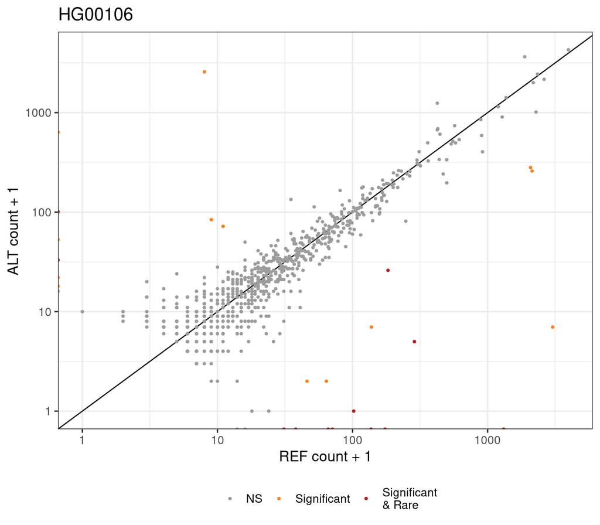

````markdown
```{r}
sample1 <- 'HG00106'
plotAllelicCounts(resAnnot[MAE_ID == sample1], rare_column = 'rare', title = sample1) + theme(legend.position = "bottom")
```
````

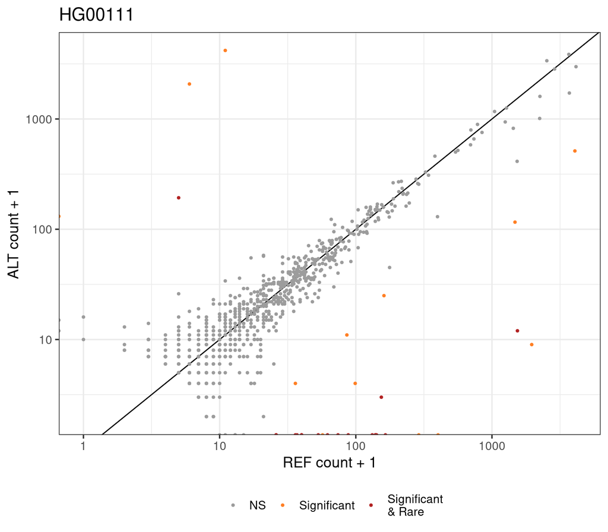

````markdown
```{r}
sample2 <- 'HG00111'
plotAllelicCounts(resAnnot[MAE_ID == sample2], rare_column = 'rare', title = sample2) + theme(legend.position = "bottom")
```
````

## Gene Prioritization

````markdown
```{r}
# ensembleVEP requires variant_effect_predictor.pl in the PATH. For this you will likely have to manually install commandline version of https://www.ensembl.org/info/docs/tools/vep/script/vep_download.html
# Also, the manuall install threw requirement of DBI as a perl package --> instal cpanminus using apt-get install followed by cpanm DBI
library(VariantAnnotation)
```
```{r}
library(TVTB)
```
```{r}
library(annotables)
library(ensemblVEP)
```
````

```
## variant_effect_predictor.pl or vep script not found. Ensembl VEP is not installed in your path.
##
```

````markdown
```{r}
library(tidyverse)
```
````

```
## ✖ lubridate::%within%() masks IRanges::%within%()
## ✖ lubridate::second<-() masks S4Vectors::second<-()
```

````markdown
```{r}
library(data.table)
```
````

#### CASE 1

This boy was the third child of healthy non-consanguineous French parents. Pregnancy and delivery were uneventful. Early psychomotor development was normal. However, speech development was delayed, acquiring language at the age of 4. At 11, he began to experience psychomotor regression and progressive visual loss. At current (by the time of the publication) age of 47, he has severe walking difficulties, blindness, abnormal behaviour (easily frightened, sometimes aggressive) and spontaneous speech.

In our dataset, this sample is named **NA11918**.

````markdown
```{r}
# Download a list of candidates
results_link="https://i12g-gagneurweb.in.tum.de/public/workshops/RNAseq_ASHG19/input_data/outrider/results_pvalue.tsv.gz"
outrider_results_genes=fread(results_link)
```
```{r}
# Filter for the case of interest
outrider_results_genes= outrider_results_genes %>% filter(sampleID=="NA11918") %>% select(geneID) %>% unlist

# Take a look at what the gene list looks like
head(outrider_results_genes)
# Get the number of candidate genes for that case
print("The total number of candidate genes within this case:")
length(outrider_results_genes)
```
````

```
##                geneID1                geneID2                geneID3
## "ENSG00000165288.10_2" "ENSG00000179715.12_4" "ENSG00000146021.14_4"
##                geneID4                geneID5                geneID6
##  "ENSG00000115825.9_2" "ENSG00000047932.13_4" "ENSG00000119772.16_3"
## [1] "The total number of candidate genes within this case:"
## [1] 29
```

GeneIDs here are not totally in ENSEMBL format so we will have to convert to one

````markdown
```{r}
# Modify gene format
outrider_results_genes=str_extract(outrider_results_genes, "ENSG[0-9]+")

# look at the changes
head(outrider_results_genes)
```
````

```
## [1] "ENSG00000165288" "ENSG00000179715" "ENSG00000146021" "ENSG00000115825"
## [5] "ENSG00000047932" "ENSG00000119772"
```

To make it human readable gene names. we will use annotable package and filter them

````markdown
```{r}
candidate_genes=grch37 %>% filter(ensgene %in% outrider_results_genes)

# look at the results
head(candidate_genes)
```
````

```
## # A tibble: 6 × 9
##   ensgene         entrez symbol chr      start    end strand biotype description
##   <chr>            <int> <chr>  <chr>    <int>  <int>  <int> <chr>   <chr>
## 1 ENSG00000047932  57120 GOPC   6       1.18e8 1.18e8     -1 protei… golgi-asso…
## 2 ENSG00000060558   2769 GNA15  19      3.14e6 3.16e6      1 protei… guanine nu…
## 3 ENSG00000068305   4205 MEF2A  15      1.00e8 1.00e8      1 protei… myocyte en…
## 4 ENSG00000074706  26034 IPCEF1 6       1.54e8 1.55e8     -1 protei… interactio…
## 5 ENSG00000090674  57192 MCOLN1 19      7.59e6 7.60e6      1 protei… mucolipin 1
## 6 ENSG00000091490  23231 SEL1L3 4       2.57e7 2.59e7     -1 protei… sel-1 supp…
```

We now have the list of candidate genes and more information on what they are. We are ready to filter this list to keep only the genes that are linked to the symptoms of the case of interest.

In our case, the symptoms are:

- Developmental regression (HP:0002376)
- Ataxia(HP:0001251)
- Ophthalmoplegia (HP:0000602)
- Visual impairment (HP:0000505)

As you can see, there is an ID beside each symptom. Those are HPO term IDs, as found in the Human Phenotype Ontology [database](https://hpo.jax.org/app/).

### Annotate candidate genes with HPO terms

````markdown
```{r}
sample_HPO= c("HP:0002376","HP:0001251", "HP:0000602","HP:0000505")

sample_HPO
```
````

```
## [1] "HP:0002376" "HP:0001251" "HP:0000602" "HP:0000505"
```

#### Load gene to HPO ID file from HPO database

The Human Phenotype Ontology gives access to a very useful file, showing the link between symptoms and genes. This file is updated regularly so we recommend to **download the latest version** whenever possible.

You can download this file [here](https://hpo.jax.org/app/data/annotations).

````markdown
```{r}
# Get the file URL https://hpo.jax.org/app/data/annotations. The file has to be manually downloaded


# Read the file
gene_hpo <-fread("./phenotype_to_genes.txt", skip=1)

# Select only the columns of interest (Gene and HPO term)
gene_hpo <- gene_hpo[, c(4, 1)]
colnames(gene_hpo) <- c("Gene", "Term")

# Look at the results
head(gene_hpo)
```
````

```
##        Gene       Term
## 1:    XYLT1 HP:0025115
## 2:    XYLT2 HP:0025115
## 3:    ABCC6 HP:0025115
## 4:  ALOX12B HP:0025114
## 5:   ALOXE3 HP:0025114
## 6: LORICRIN HP:0025114
```

#### Get a subset of genes that could match the syptoms

Now that we have downloaded that file, we want to keep only the genes that are phenotypically relevant to the case.

1. Filter for HPO terms corresponding to the case
2. Obtain the Ensembl IDs for the genes that are associated to those HPO terms

````markdown
```{r}
genes_hpo_case=gene_hpo %>%
  filter(Term %in% sample_HPO) %>%
  left_join(grch37, by=c("Gene"="symbol"))
```
```{r}
genes_hpo_case = genes_hpo_case %>% select(ensgene) %>% unique %>% unlist

head(genes_hpo_case)
length(genes_hpo_case)
```
````

```
##          ensgene1          ensgene2          ensgene3          ensgene4
## "ENSG00000134242" "ENSG00000206450" "ENSG00000223532" "ENSG00000224608"
##          ensgene5          ensgene6
## "ENSG00000228964" "ENSG00000232126"
## [1] 1967
```

#### Subset the list of genes to outlier candidates

Here the assumption is that if there is an expression perturbation on the causal gene, this gene is somehow linked to some of the symptoms of the patient.  
So we want to **filter** the list of genes somehow linked to the patients symptoms (listed in `genes_hpo_case`) for the one obtained as candidates in previous work.

````markdown
```{r}
# Filter outlier genes for genes linked to the phenotype.
candidate_genes.hpo=candidate_genes %>% filter(ensgene %in% genes_hpo_case)

# Get the number of genes left
cat("The number of outlier genes left after filtering associated with the disease:")
length(candidate_genes.hpo$ensgene)

# Take a look at the results
candidate_genes.hpo
```
````

```
## The number of outlier genes left after filtering associated with the disease:[1] 5
## # A tibble: 5 × 9
##   ensgene         entrez symbol chr      start    end strand biotype description
##   <chr>            <int> <chr>  <chr>    <int>  <int>  <int> <chr>   <chr>
## 1 ENSG00000090674  57192 MCOLN1 19      7.59e6 7.60e6      1 protei… mucolipin 1
## 2 ENSG00000119772   1788 DNMT3A 2       2.55e7 2.56e7     -1 protei… DNA (cytos…
## 3 ENSG00000136717    274 BIN1   2       1.28e8 1.28e8     -1 protei… bridging i…
## 4 ENSG00000151474  55691 FRMD4A 10      1.37e7 1.45e7     -1 protei… FERM domai…
## 5 ENSG00000170004   1107 CHD3   17      7.79e6 7.82e6      1 protei… chromodoma…
```

### Annotate with variant information

We can go further and annotate our candidate with the variant information for the case.

To do so, we need to transform the candidate gene list into the right format so that we can use the genes when reading in the [VCF](https://www.internationalgenome.org/wiki/Analysis/Variant%20Call%20Format/vcf-variant-call-format-version-40/) file in R.

#### Build a GRanges object with the genes obtain in previous steps

We use R packages that have been developped to handle and filter VCF files. Here, we want to upload only the part of the VCF file that is in regions of interest (i.e., our candidate genes). We can do this by giving as an input an object of type [GRanges](https://web.mit.edu/~r/current/arch/i386_linux26/lib/R/library/GenomicRanges/html/GRanges-class.html).

The next steps are transforming our list of candidate genes to the right format so that we can proceed with the analysis.

1. Change the start and end position to include potential regulatory regions (+/- 1kb here). Note that you can customize this distance or use the gene coordinates.

````markdown
```{r}
# Extending the start/end coordinates to 1kb around the gene of interest
candidate_genes=candidate_genes.hpo %>%
        mutate(new_start=pmin(start,end)-1e3, new_end=pmax(start,end)+1e3)

# Take a look at the results
head(candidate_genes)
```
````

```
## # A tibble: 5 × 11
##   ensgene entrez symbol chr    start    end strand biotype description new_start
##   <chr>    <int> <chr>  <chr>  <int>  <int>  <int> <chr>   <chr>           <dbl>
## 1 ENSG00…  57192 MCOLN1 19    7.59e6 7.60e6      1 protei… mucolipin 1   7586512
## 2 ENSG00…   1788 DNMT3A 2     2.55e7 2.56e7     -1 protei… DNA (cytos…  25454845
## 3 ENSG00…    274 BIN1   2     1.28e8 1.28e8     -1 protei… bridging i… 127804603
## 4 ENSG00…  55691 FRMD4A 10    1.37e7 1.45e7     -1 protei… FERM domai…  13684706
## 5 ENSG00…   1107 CHD3   17    7.79e6 7.82e6      1 protei… chromodoma…   7787124
## # ℹ 1 more variable: new_end <dbl>
```

2. Transform data frame into GRanges object

````markdown
```{r}
# Create a GRanges Object
candidate_genes.gr=makeGRangesFromDataFrame(
        candidate_genes, ignore.strand=TRUE,
        start.field="new_start",end.field="new_end")

# Add gene names to GRanges object
names(candidate_genes.gr)=candidate_genes$ensgene

candidate_genes.gr
```
````

```
## GRanges object with 5 ranges and 0 metadata columns:
##                   seqnames              ranges strand
##                      <Rle>           <IRanges>  <Rle>
##   ENSG00000090674       19     7586512-7599895      *
##   ENSG00000119772        2   25454845-25566459      *
##   ENSG00000136717        2 127804603-127865931      *
##   ENSG00000151474       10   13684706-14505141      *
##   ENSG00000170004       17     7787124-7817078      *
##   -------
##   seqinfo: 4 sequences from an unspecified genome; no seqlengths
```

#### Load a VCF file

````markdown
```{r}
vcfFile <- "./variants/1000G_subset_exome.vep.vcf.gz"
# index the VCF file
indexVcf(vcfFile)

# Create a reference
vcfFile <- TabixFile(vcfFile)

vcfFile
```
````

```
## class: VcfFile
## path: ./variants/1000G_subset_exome.vep.vcf.gz
## index: ./variants/1000G_subset_exome.vep.vcf.gz.tbi
## isOpen: FALSE
## yieldSize: NA
## class: TabixFile
## path: ./variants/1000G_subset_exome.vep.vcf.gz
## index: ./variants/1000G_subset_exome.vep.vcf.gz.tbi
## isOpen: FALSE
## yieldSize: NA
```

#### Read in the VCF file for the sample of interest

For demo purposes we can look at sample of interest and the overlapping genes of interest that consists or may consist the variants

````markdown
```{r}
params = ScanVcfParam(samples = "NA11918", which = candidate_genes.gr)

# read the vcf file filter the data using the parameter file created above.
vcf_rng <- readVcf(vcfFile, "hg19", params)
```
```{r}
head(rowRanges(vcf_rng),3)
```
````

```
## GRanges object with 3 ranges and 5 metadata columns:
##               seqnames    ranges strand |    paramRangeID            REF
##                  <Rle> <IRanges>  <Rle> |        <factor> <DNAStringSet>
##    rs61758432        2  25457190      * | ENSG00000119772              G
##   rs377534934        2  25458709      * | ENSG00000119772              G
##   rs143620117        2  25459792      * | ENSG00000119772              C
##                              ALT      QUAL      FILTER
##               <DNAStringSetList> <numeric> <character>
##    rs61758432                  A       100        PASS
##   rs377534934                  A       100        PASS
##   rs143620117                  T       100        PASS
##   -------
##   seqinfo: 86 sequences from hg19 genome
```

#### Filter for heterozygous or homozygous Alt and genes of interest

In genomics and sequencing, the term “ALT” typically refers to alternate contigs or alternate haplotypes. A contig is a contiguous sequence of DNA that has been assembled from fragments of sequenced DNA. Alternate contigs represent different versions of a particular region of the genome that may exist in a population or individual. Haplotypes are sets of alleles, or alternative forms of a gene, that are inherited together on a single chromosome. Alternate haplotypes represent different combinations of alleles that may exist in a population or individual.

- **ALT haplotypes in population genetics:** In population genetics, ALT haplotypes are used to study the genetic diversity of a population. By comparing the haplotypes of different individuals, researchers can identify common and rare variants and track the spread of mutations through a population.
- **ALT alleles in clinical genetics:** In clinical genetics, ALT alleles are used to identify individuals who may be at risk of genetic disorders. For example, some genetic disorders are caused by the presence of a particular combination of ALT alleles.

````markdown
```{r}
candidate_genes

# Create a filter on variants hetero or homozyg alt
Hetfilt <- FilterRules(list(HetorHomAlt =
        function(x) geno(x)$GT %in% c("0|1", "1|1", "1|0")))

# create a filter to keep only candidate gene annotations
GeneFilt <- VcfVepRules(exprs = list(Cand_genes =
        bquote(SYMBOL %in% .(candidate_genes$symbol) )))
# Combine filters
combinedPreFilters <- VcfFilterRules(Hetfilt, GeneFilt)

# apply them on the vcf
vcf_het_cand <- subsetByFilter(vcf_rng, combinedPreFilters)

rowRanges(vcf_het_cand)
```
````

```
## # A tibble: 5 × 11
##   ensgene entrez symbol chr    start    end strand biotype description new_start
##   <chr>    <int> <chr>  <chr>  <int>  <int>  <int> <chr>   <chr>           <dbl>
## 1 ENSG00…  57192 MCOLN1 19    7.59e6 7.60e6      1 protei… mucolipin 1   7586512
## 2 ENSG00…   1788 DNMT3A 2     2.55e7 2.56e7     -1 protei… DNA (cytos…  25454845
## 3 ENSG00…    274 BIN1   2     1.28e8 1.28e8     -1 protei… bridging i… 127804603
## 4 ENSG00…  55691 FRMD4A 10    1.37e7 1.45e7     -1 protei… FERM domai…  13684706
## 5 ENSG00…   1107 CHD3   17    7.79e6 7.82e6      1 protei… chromodoma…   7787124
## # ℹ 1 more variable: new_end <dbl>
## GRanges object with 3 ranges and 5 metadata columns:
##                  seqnames    ranges strand |    paramRangeID            REF
##                     <Rle> <IRanges>  <Rle> |        <factor> <DNAStringSet>
##      rs184117677       10  14050013      * | ENSG00000151474              T
##      rs768736321       19   7592731      * | ENSG00000090674              A
##   19:7593098_C/T       19   7593098      * | ENSG00000090674              C
##                                 ALT      QUAL      FILTER
##                  <DNAStringSetList> <numeric> <character>
##      rs184117677                  C       100        PASS
##      rs768736321                  C       255        PASS
##   19:7593098_C/T                  T       255        PASS
##   -------
##   seqinfo: 86 sequences from hg19 genome
```